# Wikipedia Revisions

October 10, 2017  
Author: Eni Mustafaraj  
(This notebook was revised on Oct 15, don't use the one from Oct 10 that was shared via email.)

This notebook shows:

- how to work with the **mwclient** module to exlore Wikipedia pages
- how to get revisions of an article and find out the users who contributed

**Table of Content**

1. Installing the `mwclient` module
2. Connecting to a site and working with pages
3. The Wellesley College page
4. Exploring the Wellesley page revisions  
   .. Using the pickle module to save revisions  
   .. Find users in revisions  
   .. Working with revision timestamps
5. YOUR TASK: Exploring timestamps

**NOTE:** If you cannot complete all parts of the task in section 5 (especially Task 3), it's okay for the moment, you can return to it later. It's a good example of using advanced Python skills.

## 1. Installing the `mwclient` module

In this notebook I've used the module [mwclient](http://mwclient.readthedocs.io/en/latest/index.html). You'll need to install it before starting to work in this notebook.

You can install a package from within the notebook, with the following command:

```
!pip install mwclient
```

```python
# do the installation
!pip3 install mwclient
```

```python
# test the installation
import mwclient
```

### Suppress warnings in jupyter

For various reasons, jupyter shows sometimes warnings from libraries not related to what we're doing.  
I'm suppressing these warnings for the sake of visual clarity.

```python
import warnings
warnings.filterwarnings(action='ignore')
```

## 2. Connecting to a wiki site and getting pages

There are many wiki websites. We need to provide the URL of the one we will work with, in our case the English Wikipedia.

```python
from mwclient import Site
site = Site('en.wikipedia.org')
```

It's possible to search for pages based on a simple query term, given that we will search within the `site`:

```python
page = site.pages['Wellesley']
page
```

```
<Page object 'b'Wellesley'' for <Site object 'en.wikipedia.org/w/'>>
```

And we can read the text of the page, in this case, a disambiguation page with links to many pages that contain the word "Wellesley":

```python
print(page.text())
```

```
'''Wellesley''' may refer to:
{{TOC right}}
== Ships ==
* [[HMS Wellesley|HMS ''Wellesley'']], name of two Royal Navy ships

== People ==
===Dukes of Wellington===
* [[Arthur Wellesley, 1st Duke of Wellington]] (1769–1852), British soldier, statesman, and Prime Minister of the United Kingdom
* [[Arthur Wellesley, 2nd Duke of Wellington]] (1807–1884), British politician
* [[Henry Wellesley, 3rd Duke of Wellington]] (1846–1900), British soldier and politician
* [[Arthur Wellesley, 4th Duke of Wellington]] (1849–1934), British soldier
* [[Arthur Wellesley, 5th Duke of Wellington]] (1876–1941), British soldier
* [[Henry Wellesley, 6th Duke of Wellington]] (1912–1943), British soldier
* [[Gerald Wellesley, 7th Duke of Wellington]] (1885–1972), British soldier and diplomat
* [[Valerian Wellesley, 8th Duke of Wellington]] (1915–2014), British soldier
* [[Charles Wellesley, 9th Duke of Wellington]] (born 1945), British politician and businessman

===Others, including relatives of Dukes===
* [[Arthur Wellesley, Marquess of Douro]] (born 1978), British businessman
* [[Lord Charles Wellesley]] (1808–1858), British politician
* [[Charles Wellesley]] (1873–1946), American actor
* [[Elizabeth Wellesley, Duchess of Wellington]] (1820–1904), Mistress of the Robes
* [[Lady Elizabeth Wellesley]] (born 1918), British socialite
* [[Lord George Wellesley]] (1889–1967), British soldier
* [[Henry Wellesley, 1st Baron Cowley]] (1773–1847), Irish diplomat
* [[Richard Wellesley, 1st Marquess Wellesley]] (1760–1842), Irish peer, statesman, and Governor-General of India
* [[Walter Wellesley]] (c. 1470–1539), prior of Great Connell priory and bishop of Kildare

== Places and institutions ==
* [[Wellesley, Massachusetts]], United States
** [[Wellesley College]], private women's liberal arts college in Wellesley, Massachusetts
** [[Wellesley High School]], public high school in Wellesley, Massachusetts
* [[Wellesley College (New Zealand)]], private boys only independent primary school in New Zealand
* [[Wellesley, Ontario]], Canada, a township
* [[Province Wellesley]], Penang, Malaysia, known in Malay as Seberang Prai

==Other==
* The [[Vickers Wellesley]], 1930s single-engine medium bomber of the Royal Air Force
* [[Wellesley (TTC)]], a subway station in Toronto, Ontario
* Wellesley marriage, defunct term for (not necessarily sexual) same-sex cohabitation, see [[Boston marriage]]

{{disambiguation|geo|surname}}
```

### 2.a What else does a page contain?

Let's looks at some properties that the page contains:

**Categories:** Most pages in Wikipedia are assigned categories, which we can access:

```python
for p in page.categories():
    print(p)
```

```
<Category object 'b'Category:Disambiguation pages'' for <Site object 'en.wikipedia.org/w/'>>
<Category object 'b'Category:Disambiguation pages with surname-holder lists'' for <Site object 'en.wikipedia.org/w/'>>
<Category object 'b'Category:All disambiguation pages'' for <Site object 'en.wikipedia.org/w/'>>
<Category object 'b'Category:Place name disambiguation pages'' for <Site object 'en.wikipedia.org/w/'>>
<Category object 'b'Category:All article disambiguation pages'' for <Site object 'en.wikipedia.org/w/'>>
```

**Links:** A page has many links to other Wikipedia pages, we can access them too:

```python
links = [l for l in page.links()]
links
```

```
[<Page object 'b'Gerald Wellesley, 7th Duke of Wellington'' for <Site object 'en.wikipedia.org/w/'>>,
 <Page object 'b'Boston marriage'' for <Site object 'en.wikipedia.org/w/'>>,
 <Page object 'b'Henry Wellesley, 6th Duke of Wellington'' for <Site object 'en.wikipedia.org/w/'>>,
 <Page object 'b'Henry Wellesley, 3rd Duke of Wellington'' for <Site object 'en.wikipedia.org/w/'>>,
 <Page object 'b'Walter Wellesley'' for <Site object 'en.wikipedia.org/w/'>>,
 <Page object 'b'Wellesley High School'' for <Site object 'en.wikipedia.org/w/'>>,
 <Page object 'b'Arthur Wellesley, 2nd Duke of Wellington'' for <Site object 'en.wikipedia.org/w/'>>,
 <Page object 'b'Help:Disambiguation'' for <Site object 'en.wikipedia.org/w/'>>,
 <Page object 'b'HMS Wellesley'' for <Site object 'en.wikipedia.org/w/'>>,
 <Page object 'b'Wellesley (TTC)'' for <Site object 'en.wikipedia.org/w/'>>,
 <Page object 'b'Province Wellesley'' for <Site object 'en.wikipedia.org/w/'>>,
 <Page object 'b'Henry Wellesley, 1st Baron Cowley'' for <Site object 'en.wikipedia.org/w/'>>,
 <Page object 'b'Elizabeth Wellesley, Duchess of Wellington'' for <Site object 'en.wikipedia.org/w/'>>,
 <Page object 'b'Arthur Wellesley, 5th Duke of Wellington'' for <Site object 'en.wikipedia.org/w/'>>,
 <Page object 'b'Wellesley College (New Zealand)'' for <Site object 'en.wikipedia.org/w/'>>,
 <Page object 'b'Lord Charles Wellesley'' for <Site object 'en.wikipedia.org/w/'>>,
 <Page object 'b'Arthur Wellesley, Marquess of Douro'' for <Site object 'en.wikipedia.org/w/'>>,
 <Page object 'b'Lady Elizabeth Wellesley'' for <Site object 'en.wikipedia.org/w/'>>,
 <Page object 'b'Talk:Wellesley'' for <Site object 'en.wikipedia.org/w/'>>,
 <Page object 'b'Charles Wellesley'' for <Site object 'en.wikipedia.org/w/'>>,
 <Page object 'b'Richard Wellesley, 1st Marquess Wellesley'' for <Site object 'en.wikipedia.org/w/'>>,
 <Page object 'b'Arthur Wellesley, 4th Duke of Wellington'' for <Site object 'en.wikipedia.org/w/'>>,
 <Page object 'b'Wellesley, Ontario'' for <Site object 'en.wikipedia.org/w/'>>,
 <Page object 'b'Arthur Wellesley, 1st Duke of Wellington'' for <Site object 'en.wikipedia.org/w/'>>,
 <Page object 'b'Lord George Wellesley'' for <Site object 'en.wikipedia.org/w/'>>,
 <Page object 'b'Charles Wellesley, 9th Duke of Wellington'' for <Site object 'en.wikipedia.org/w/'>>,
 <Page object 'b'Vickers Wellesley'' for <Site object 'en.wikipedia.org/w/'>>,
 <Page object 'b'Wellesley, Massachusetts'' for <Site object 'en.wikipedia.org/w/'>>,
 <Page object 'b'Wellesley College'' for <Site object 'en.wikipedia.org/w/'>>,
 <Page object 'b'Valerian Wellesley, 8th Duke of Wellington'' for <Site object 'en.wikipedia.org/w/'>>]
```

**IMPORTANT - Lazy behavior:** Simply calling the method `links` on the page object will not give us the list of links:

```python
page.links()
```

```
<List object 'links' for <Site object 'en.wikipedia.org/w/'>>
```

We need to iterate over this object to get the links, which themselves are objects pointing to the pages.

### 2.b What's in a page object?

As we saw above, each link shows up as a page object in the list of links. This is because these are all Wikipedia articles. What can we do with these page objects?

We can use the Python built-in function `dir` to find out what properties of methods we can call on this object:

```python
onePage = links[0]
print(dir(onePage))
```

[output not shown]

```python
type(onePage)
```

```
mwclient.page.Page
```

```python
onePage.length
```

```
10443
```

```python
onePage.name
```

```
'Gerald Wellesley, 7th Duke of Wellington'
```

```python
onePage.touched
```

```
time.struct_time(tm_year=2017, tm_mon=10, tm_mday=12, tm_hour=21, tm_min=41, tm_sec=34, tm_wday=3, tm_yday=285, tm_isdst=-1)
```

## 3. The Wellesley College page

Let's get the Wellesley College page and look at its properties:

```python
wcp = site.pages['Wellesley College']
wcp.name
```

```
'Wellesley College'
```

Is it a protected page?

```python
wcp.protection
```

```
{}
```

When it was the last time that it was edited?

```python
wcp.touched # last time it was edited
```

```
time.struct_time(tm_year=2017, tm_mon=10, tm_mday=20, tm_hour=6, tm_min=17, tm_sec=29, tm_wday=4, tm_yday=293, tm_isdst=-1)
```

What is the length of the page in characters?

```python
wcp.length # length of page in characters
```

```
48532
```

Get external links from this page (links that go outside Wikipedia):

```python
extlinks = [el for el in wcp.extlinks()]
len(extlinks)
```

```
71
```

```python
extlinks[:10]
```

[output not shown]

Find all Wikipedia pages that link to Wellesley College, these are known as **backlinks**:

```python
backlinks = [el for el in wcp.backlinks()]
len(backlinks)
```

[output not shown]

```python
backlinks[:10]
```

[output not shown]

Finally, look at the links from this page to other Wikipedia pages:

```python
links = [el for el in wcp.links()]
len(links)
```

[output not shown]

```python
links[:10]
```

[output not shown]

**IMPORTANT:** The links to other pages are useful to find things that are related. Even better are reciprocal links: pages that point to each-other.

## 4. Exploring the Wellesley page revisions

We can see that the object `page` has two properties, `revision` and `revisions`, let's look at them:

```python
wcp.revision
```

```
804098189
```

```python
wcp.revisions
```

```
<bound method Page.revisions of <Page object 'b'Wellesley College'' for <Site object 'en.wikipedia.org/w/'>>>
```

The message shows that `revisions` is a method, not a property, we'll need parens to access it:

```python
wcp.revisions()
```

```
<List object 'revisions' for <Site object 'en.wikipedia.org/w/'>>
```

We can see the pattern now, most functions return **lazy objects**, because the user might not be interested in everything.  
**Get all revisions:** We can get all revisions we want by looping through the list iterator. This might take a few seconds.

```python
revisions = [rev for rev in wcp.revisions()]
len(revisions)
```

```
1764
```

```python
revisions[:3]
```

```
[{'comment': '',
  'minor': '',
  'parentid': 804098109,
  'revid': 804098189,
  'timestamp': time.struct_time(tm_year=2017, tm_mon=10, tm_mday=6, tm_hour=18, tm_min=37, tm_sec=35, tm_wday=4, tm_yday=279, tm_isdst=-1),
  'user': 'Imanh19'},
 {'comment': '',
  'minor': '',
  'parentid': 804096406,
  'revid': 804098109,
  'timestamp': time.struct_time(tm_year=2017, tm_mon=10, tm_mday=6, tm_hour=18, tm_min=36, tm_sec=59, tm_wday=4, tm_yday=279, tm_isdst=-1),
  'user': 'Imanh19'},
 {'comment': '',
  'minor': '',
  'parentid': 804095124,
  'revid': 804096406,
  'timestamp': time.struct_time(tm_year=2017, tm_mon=10, tm_mday=6, tm_hour=18, tm_min=24, tm_sec=43, tm_wday=4, tm_yday=279, tm_isdst=-1),
  'user': 'Imanh19'}]
```

**IMPORTANT:** You notice that it takes a while to get the revisions. It is wise to dump the results into a file.

Let's try JSON (but anticipate an error, because each dictionary contains one item that is an object of type time.struct_time, and the JSON format doesn't accept objects, only primitive values.)

```python
import json
with open("wellesleycollegerevisions.json", 'w') as jsonFile:
    json.dump(revisions, jsonFile)
```

[output not shown]

### 4.a Using `pickle` to store Python objects

It turns out, we cannot use JSON for Python objects, this is where modules such as `pickle` or `cPickle` enter the scene. Such modules do **serialization**, that is, saving data in binary format. To learn more about these modules, you can read [this page](https://pymotw.com/2/pickle/).

```python
# in case cPickle is installed, it will use it, because faster
try:
    import cPickle as pickle
except:
    import pickle
```

The interface for `pickle` is the same as that for `json`: both use the two functions: `load` and `dump`.

```python
with open("wellesleycollegerevisions.pck", 'w') as pckFile:
    pickle.dump(revisions, pckFile)
```

[output not shown]

**Loading the file:** If you have a pickled file with your data, then, you can access it like this:

```python
revisionsList = pickle.load(open("wellesleycollegerevisions.pck"))
len(revisionsList)
```

[output not shown]

### 4.b Find users in revisions

Each revision is stored as a Python dictionary, so we can easily extract the users:

```python
users = [rev['user'] for rev in revisions]
```

We'll use the `Counter` class to create a dict of users with their counts and then print these users based on the number of edits, with the most common edits at the top:

```python
from collections import Counter

usersDct = Counter(users)
usersDct.most_common(10)
```

```
[('Interestingstuffadder', 46),
 ('Contributor321', 34),
 ('ElKevbo', 30),
 ('Classicfilms', 26),
 ('Catamorphism', 25),
 ('Cellmesellme', 20),
 ('Vadalium92', 18),
 ('SmackBot', 15),
 ('86.66.141.94', 15),
 ('Melmoththewanderer', 14)]
```

Let's check some of CS 234 editors of the page:

```python
usersDct['Imanh19']
```

```
3
```

```python
usersDct['Angelinahli']
```

```
6
```

How many unique users have edited this page? I'm using the string method `format` to create a sentence.

```python
print("{} unique users have edited {} times the {} page.".format(len(usersDct),
                                                                 len(revisions),
                                                                 wcp.name))
```

```
948 unique users have edited 1764 times the Wellesley College page.
```

### 4.c Working with timestamps

Each revision contains a timestamp. Let's convert that to a datetime object to make it easier to work with it. **NOTE:** If you haven't completed yet the Notebok Time, Datetime, Dateutil, don't worry, you'll get to do that soon.

```python
ts = revisions[0]['timestamp']
ts
```

```
time.struct_time(tm_year=2017, tm_mon=10, tm_mday=6, tm_hour=18, tm_min=37, tm_sec=35, tm_wday=4, tm_yday=279, tm_isdst=-1)
```

```python
type(ts)
```

```
time.struct_time
```

The following modules will work together to make the conversion from `timestruct` to `datetime`:

```python
from time import mktime
from datetime import datetime
datetime.fromtimestamp(mktime(ts))
```

```
datetime.datetime(2017, 10, 6, 18, 37, 35)
```

Now that we have a datetime object, we can do many things:

1. group number of revisions by day
2. group number of revisions by month or year
3. group revisions by user revisions per day

```python
dt = datetime.fromtimestamp(mktime(ts))
print( dt.year)
print( dt.month)
print( dt.day)
```

```
2017
10
6
```

```python
print (dt.date())
```

```
2017-10-06
```

**Example: What was the day with most revisions?**

```python
def createDateTime(rev):
    return datetime.fromtimestamp(mktime(rev['timestamp']))

dates = [str(createDateTime(rev).date()) for rev in revisions]
dates[:10]
```

```
['2017-10-06',
 '2017-10-06',
 '2017-10-06',
 '2017-10-06',
 '2017-10-06',
 '2017-09-30',
 '2017-09-30',
 '2017-09-29',
 '2017-09-29',
 '2017-09-29']
```

**TASK for you:** Unpack this expression `str(createDateTime(rev).date())` to understand what is happening.

The function `createDateTime(rev)` takes in a revision dictionary (**rev**), and gets the timestamp. It converts it from a `timestruct` object to a `datetime` object and returns that `datetime` object representing the timestamp. The expression `str(createDateTime(rev).date())`, gets the `datetime` version of the timestamp in the revision `rev` and extracts the date with the function `.date()` and turns it into a string using `str()`

**Find days with most edits**

We can do this in the same way we found the users with most edits, using the `Counter` constructor:

```python
datesDct = Counter(dates)
datesDct.most_common(10)
```

```
[('2008-07-10', 16),
 ('2006-08-09', 14),
 ('2008-07-23', 14),
 ('2009-04-05', 13),
 ('2017-09-29', 13),
 ('2010-06-29', 13),
 ('2014-07-08', 12),
 ('2012-07-16', 12),
 ('2007-02-22', 10),
 ('2014-12-05', 10)]
```

## 5. YOUR TASK: Exploring Timestamps

Let's create a list of timestamps using the helper function `createDateTime` that we wrote in the previous sections:

```python
timestamps = [createDateTime(rev) for rev in revisions]
timestamps[:3]
```

```
[datetime.datetime(2017, 10, 6, 18, 37, 35),
 datetime.datetime(2017, 10, 6, 18, 36, 59),
 datetime.datetime(2017, 10, 6, 18, 24, 43)]
```

We can write code to extract the `year` portion of each timestamp:

```python
timestamps[0].year
```

```
2017
```

**Task 1:** Create the list of edits by year. The excepted result should be something like this:

```
2003 15
2004 38
2005 80
2006 267
2007 162
2008 223
2009 155
2010 134
2011 68
2012 118
2013 89
2014 103
2015 95
2016 113
2017 104
```

```python
allYears = [ts.year for ts in timestamps]
allYearsCount = Counter(allYears)

for year in sorted(allYearsCount.keys()):
    print(year, allYearsCount[year])
```

```
2003 15
2004 38
2005 80
2006 267
2007 162
2008 223
2009 155
2010 134
2011 68
2012 118
2013 89
2014 103
2015 95
2016 113
2017 104
```

**Task 2:** Build a histogram for this data. (You learned to build histograms in the first week: Data Visualization notebook). Try to avoid using hard-coded data. Imagine that you might want to use this function that creates the histogram for other pages, so you'll not know in advance which years are available.

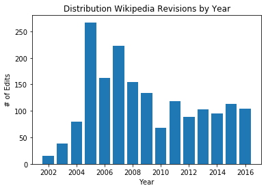

```python
import matplotlib.pyplot as plt
# the following line is used to make sure that the plots will show inline in the notebook
%matplotlib inline

def yearHistogram(allYearsCount):
    years = sorted(allYearsCount.keys())
    freq_years = [allYearsCount[y] for y in years]
    plt.bar([y-1 for y in years], freq_years)
    #plt.xticks(years)
    plt.xlabel("Year")
    plt.ylabel("# of Edits")
    plt.title("Distribution Wikipedia Revisions by Year")
    plt.show()

yearHistogram(allYearsCount)
```

**Task 3 (Challenging):** Who are the most consistent users over time? That is, which users have been coming in different years to make their edits?

**Hint:** Use `zip` with the two lists `users` and `timestamps` that you created above.  
Use the `defaultdict` from `collections` to easily create a dict of users and counts by year. You can have a dict like this one: `defaultdict(Counter)`.  
Simultenaous assignment of two variables in for loops (also known as tuple assignment) is also going to be useful.

The answer is given below:

```
Edits of user ElKevbo distributed by years: {2016: 6, 2017: 2, 2012: 2, 2013: 11, 2014: 7, 2015: 2}
Edits of user Contributor321 distributed by years: {2016: 17, 2017: 12, 2013: 3, 2014: 1, 2015: 1}
Edits of user FrescoBot distributed by years: {2010: 1, 2012: 1, 2014: 1, 2015: 1}
Edits of user Yobot distributed by years: {2016: 4, 2012: 1, 2014: 1, 2015: 2}
Edits of user SmackBot distributed by years: {2008: 5, 2009: 4, 2010: 1, 2007: 5}
```

As we can see, there are a lot of bots doing edits over the years.

```python
from collections import defaultdict
user_timestamp = zip(users, allYears)
user_count= defaultdict(dict)
for u in user_timestamp:
    usr, ts = u
    user_count[usr][ts] = user_count.get(ts, 0) + 1

for u in user_count.keys():
    print("Edits of user ", u, "distributed by years:", user_count[u])
```

```
Edits of user  Ktr101 distributed by years: {2009: 1, 2012: 1}
Edits of user  69.210.36.23 distributed by years: {2007: 1}
Edits of user  157.233.20.175 distributed by years: {2008: 1}
Edits of user  203.126.139.254 distributed by years: {2010: 1}
Edits of user  Jylanthas distributed by years: {2009: 1}
Edits of user  138.110.235.83 distributed by years: {2010: 1}
Edits of user  75.110.98.103 distributed by years: {2016: 1}
Edits of user  Leeearnest~enwiki distributed by years: {2008: 1}
Edits of user  Sfphotocraft distributed by years: {2006: 1}
Edits of user  SoutheastMaster distributed by years: {2008: 1}
Edits of user  2605:A601:E0C:6300:996D:68C0:FB03:AF2C distributed by years: {2017: 1}
Edits of user  66.41.122.211 distributed by years: {2009: 1}
Edits of user  Corkythehornetfan distributed by years: {2017: 1}
Edits of user  Gettingtoit distributed by years: {2005: 1}
Edits of user  66.31.21.58 distributed by years: {2011: 1}
Edits of user  64.185.194.15 distributed by years: {2013: 1}
Edits of user  Oddharmonic distributed by years: {2008: 1}
Edits of user  96.237.237.39 distributed by years: {2009: 1}
Edits of user  Ueutyi distributed by years: {2016: 1}
Edits of user  209.159.241.225 distributed by years: {2008: 1}
Edits of user  Yu Sang Chang distributed by years: {2010: 1}
Edits of user  149.130.211.130 distributed by years: {2006: 1}
Edits of user  Katherinehawk distributed by years: {2008: 1}
Edits of user  Fisheriesmgmt distributed by years: {2015: 1}
Edits of user  137.158.153.203 distributed by years: {2014: 1}
Edits of user  Yobot distributed by years: {2016: 1, 2012: 1, 2014: 1, 2015: 1}
Edits of user  143.231.249.138 distributed by years: {2017: 1}
Edits of user  Emu14 distributed by years: {2017: 1}
Edits of user  Makiebaby distributed by years: {2011: 1}
Edits of user  ThreeBlindMice distributed by years: {2006: 1}
Edits of user  Stevenliuyi distributed by years: {2010: 1}
Edits of user  Jhuang distributed by years: {2005: 1}
Edits of user  192.212.253.17 distributed by years: {2006: 1}
Edits of user  67.161.180.75 distributed by years: {2007: 1}
Edits of user  Windowlicker6667 distributed by years: {2008: 1}
Edits of user  That Guy, From That Show! distributed by years: {2006: 1}
Edits of user  149.130.223.239 distributed by years: {2010: 1}
Edits of user  24.46.30.244 distributed by years: {2006: 1}
Edits of user  121.6.193.219 distributed by years: {2014: 1}
Edits of user  Rosenzweig distributed by years: {2008: 1, 2009: 1, 2005: 1}
```

[output cut: 893 more lines]

```
Edits of user  66.30.32.52 distributed by years: {2004: 1}
Edits of user  98.67.170.121 distributed by years: {2010: 1}
Edits of user  MBisanz distributed by years: {2008: 1}
Edits of user  Catapult distributed by years: {2006: 1}
Edits of user  Tamarleigh distributed by years: {2013: 1}
Edits of user  74.88.196.81 distributed by years: {2010: 1}
Edits of user  Othtvd distributed by years: {2014: 1}
Edits of user  Erbanb distributed by years: {2011: 1}
Edits of user  Sweet buttuery tart crust distributed by years: {2008: 1}
Edits of user  2001:18E8:2:1320:3D8D:6049:4FA8:6291 distributed by years: {2012: 1}
Edits of user  JaGa distributed by years: {2008: 1}
Edits of user  Shizane distributed by years: {2006: 1}
Edits of user  David Sturtevant distributed by years: {2013: 1}
Edits of user  206.126.163.20 distributed by years: {2010: 1}
Edits of user  DFS454 distributed by years: {2009: 1}
```

### Challenge: Create a HeatMap

```python
import plotly.graph_objs as go
import plotly.plotly as py
import copy

#create a default dictionary where for each of 31 days, the edits is 0
default_date_dict = {}
for i in range(1, 32):
    #first two lines convert days to '01' or '12' format for dates
    day = '0' + str(i)
    day = day[-2:]
    default_date_dict[day] = 0
#defaultdict uses a copy of this dictionary as default
date_count = defaultdict(lambda:dict(default_date_dict))

#for each year/month combo in timestamps, creates a dict of dicts
#key is year/month and val is dict of date keys and edit values
for ts in timestamps:
    year_month = str(ts.date())[:7]
    day = str(ts.date())[-2:]
    date_count[year_month][day] = date_count[year_month].get(day, 0) + 1

y_vals = sorted(list(date_count.keys()))
x_vals = [i for i in range(1, 32)]
z_vals = []
for y in y_vals:
    z_vals.append(list(date_count[y].values()))

data = [go.Heatmap(z = z_vals, x = x_vals, y = y_vals)]
py.iplot(data, filename='heatmap')
```

```
High five! You successfully sent some data to your account on plotly. View your plot in your browser at https://plot.ly/~neha.vellanki/0 or inside your plot.ly account where it is named 'heatmap'
```

[interactive chart not shown]